# INFO550 Report

Yutong Jin

# Introduction

# Data Analysis

The marginal association between time-to-event and each covariate was summarized in Table 1). Except for predetermined confounding effects of BMI/ Obesity status, diabetes history (DM) and hypertension history (HTN), no other confounders showed marginal survival differences in univariate analysis. The marginal Kaplan-Meier plots (Figure 1) also justified this phenomenon.

The final stratified Obesity-included Cox-PH model was: (Table 2)
$$h(t|\mathbf{X})=h_0(t)exp{-0.215\times PTSD-0.176\times Obese+1.521\times PTSD\times Obese-0.039\times HTN+0.448\times DM}$$

Adjusting for hypertension and diabetes history, among non-obese patients, the relative risk of having REM sleep of PTSD patients compared to non-PTSD patients was 0.806 (95% CI: 0.393–1.655). Adjusting for hypertension and diabetes history, among obese patients, the relative risk of having REM sleep of PTSD patients compared to non-PTSD patients was 3.689 (95% CI: 1.624–8.38). We referred to them as the confounder-adjusted association between PTSD and time to the occurrence of REM sleep stratified by obesity status. The difference between two association was statistically significant (p=0.008). It implied that among non-obese group, PTSD patients were not significantly associated with shorter time to the occurrence of REM sleep. However, among obese group, PTSD patients were more likely to have shorter time to the occurrence of REM sleep. The association in obese patients was significantly different from the association in non-obese patients.

# Appendix Tables/Figures

Table 1. Summary Statistics by Cox-PH Model with Respect to Categorical Covariate

| Covariates | Comparison | Relative.Risk | Lower0.95 | Upper0.95 | p.value |
| --- | --- | --- | --- | --- | --- |
| Obesity Status | Yes vs. No | 1.174 | 0.741 | 1.860 | 0.494 |
| Hypertension History | Yes vs. No | 0.993 | 0.632 | 1.561 | 0.976 |
| High Blood Cholesterol | Yes vs. No | 1.203 | 0.759 | 1.906 | 0.430 |
| Diabetes | Yes vs. No | 1.340 | 0.774 | 2.318 | 0.294 |
| PTSD | Yes vs. No | 1.343 | 0.805 | 2.243 | 0.257 |
| Marital Status | Widowed | 0.541 | 0.074 | 3.940 | 0.791 |
| (ref) Married | Divorced | 0.935 | 0.499 | 1.750 | 0.791 |
|  | Separated | 1.225 | 0.381 | 3.943 | 0.791 |
|  | Never Married | 0.527 | 0.162 | 1.713 | 0.791 |
| Employment Status | Employed(Part-time) | 1.861 | 0.755 | 4.583 | 0.128 |
| (ref) Employed-full time | Unemployed |  |  |  | 0.128 |
|  | Unable to Work due to Disability | 2.344 | 0.774 | 7.094 | 0.128 |
|  | Retired | 1.920 | 1.082 | 3.409 | 0.128 |
| Education | High School | 2.171 | 0.286 | 16.483 | 0.577 |
| (ref) Less than High School | Some College or Associate | 1.767 | 0.240 | 13.022 | 0.577 |
|  | College Degree | 2.900 | 0.372 | 22.583 | 0.577 |
|  | Graduate Education/Degree | 1.753 | 0.226 | 13.582 | 0.577 |

Table 2. Model Fitting Results for Obesity-included Cox-PH Regression Model

|  | Estimate | Std.Err | Z.value | p.value |
| --- | --- | --- | --- | --- |
| PTSD | -0.2154574 | 0.3670981 | -0.5869205 | 0.5572571 |
| Obesity | -0.1763472 | 0.3031318 | -0.5817508 | 0.5607345 |
| HTN | -0.0385600 | 0.2553707 | -0.1509964 | 0.8799786 |
| DM | 0.4482652 | 0.3093988 | 1.4488265 | 0.1473860 |
| PTSD*Obesity | 1.5207207 | 0.5759860 | 2.6402045 | 0.0082856 |

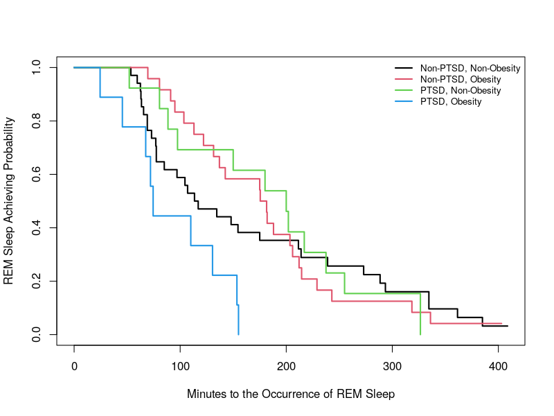

Figure 1. Kaplan-Meier Plot